# Impact of Severe Weather Events (USA)

Thursday, December 26, 2015

### Severe weather events impacting the economic and population health across the United States from 1950 to 2011.

### Synopis

The aim of this report is to explore and identify which major weather events across the United States are most harmful with respect to population health, i.e. fatalities and injuries; and which types of events have the greatest economic consequences with respect to property damage and crop damage. To identify these events, I explored and processed raw data from the U.S. National Oceanic and Atmospheric Administrations (NOAA) storm database. This database tracks and records characteristics of major weather events including the date, location and estimates of injuries, fatalities and damage incurred. Using data specifically from 1996 (the most complete and reliable records) I was able to identify the top weather events impacting popultion health with excessive heat responsible for most fatalities, and tornado events responsible for most injuries. With respect to economic impact, hurricane/typhoon events contributed most to the cost of damage.

### Loading and Data Processing

Data was obtained from the [Storm Events Database](https://www.ncdc.noaa.gov/stormevents/).

For this report we obtained files for the years [1950 to November 2011](https://d396qusza40orc.cloudfront.net/repdata%2Fdata%2FStormData.csv.bz2).

Documentation from [Storm Data Documentation](https://d396qusza40orc.cloudfront.net/repdata%2Fpeer2_doc%2Fpd01016005curr.pdf) was used to decipher variable names.

Supporting Weather event infomation was obtained from [FAQ](https://d396qusza40orc.cloudfront.net/repdata%2Fpeer2_doc%2FNCDC%20Storm%20Events-FAQ%20Page.pdf).

Storm Events Database Record updates and changes can be found [here](http://www.ncdc.noaa.gov/stormevents/details.jsp). This is of particular relevance to the data subset (from 1996 only) chosen for final analysis.

#### Downloading and Reading Data into R

The data for this report comes in the form of a comma-separated-value file compressed via the bzip2 algorithm to reduce its size. Note, for data processing and analysis it’s assumed relevant packages are installed and loaded.

```r
# Data download
#if(!file.exists("./data")) {dir.create("./data")}      #create a data dir if it doesn't exist
#fileUrl <- 'https://d396qusza40orc.cloudfront.net/repdata%2Fdata%2FStormData.csv.bz2'
#download.file(fileUrl, destfile='./data/stormData.csv.bz2')  # Create file name and download dataset
```

```r
library(dplyr)
library(knitr)
library(markdown)
#read data to R
dataSet <- read.csv('./data/stormData.csv.bz2', sep=',', header=TRUE)
```

After reading the data in we check the dimensions, the first few rows and the variable types.

```r
dim(dataSet)
```

```
## [1] 902297     37
```

```r
#str(dataSet)
head(dataSet,2)
```

```
##   STATE__          BGN_DATE BGN_TIME TIME_ZONE COUNTY COUNTYNAME STATE
## 1       1 4/18/1950 0:00:00     0130       CST     97     MOBILE    AL
## 2       1 4/18/1950 0:00:00     0145       CST      3    BALDWIN    AL
##    EVTYPE BGN_RANGE BGN_AZI BGN_LOCATI END_DATE END_TIME COUNTY_END
## 1 TORNADO         0                                               0
## 2 TORNADO         0                                               0
##   COUNTYENDN END_RANGE END_AZI END_LOCATI LENGTH WIDTH F MAG FATALITIES
## 1         NA         0                        14   100 3   0          0
## 2         NA         0                         2   150 2   0          0
##   INJURIES PROPDMG PROPDMGEXP CROPDMG CROPDMGEXP WFO STATEOFFIC ZONENAMES
## 1       15    25.0          K       0
## 2        0     2.5          K       0
##   LATITUDE LONGITUDE LATITUDE_E LONGITUDE_ REMARKS REFNUM
## 1     3040      8812       3051       8806              1
## 2     3042      8755          0          0              2
```

Looking at the documentation in the NOAA web site, specifically [here](http://www.ncdc.noaa.gov/stormevents/details.jsp), it highlights changes in the data collection and processing procedures over time. We can see that all event types are most complete (and defined) from 1996 to the present (48 from Directive 10-1605). Therefore, for this report we will explore data post 1996.

Before We can do this we will change the date format to allow subsetting of specific dates.

```r
#First reformat the date column
dataSet$BGN_DATE <- strptime(dataSet$BGN_DATE, '%m/%d/%Y %H:%M:%S')
dataSet$BGN_DATE <- as.Date(dataSet$BGN_DATE)
```

And now we subset for events from 1996 onwards

```r
#Filter for post 1996
data96 <- subset(dataSet, BGN_DATE >= '1996-1-1')
```

To assist exploratory analysis of the data we can filter for only variables of importance. This reduces the dataset from 902297 to 653530 entries.

```r
#library(dplyr)
# Select relevant variables
stormData <- select(data96, BGN_DATE, EVTYPE, FATALITIES, INJURIES, PROPDMG, PROPDMGEXP, CROPDMG, CROPDMGEXP)
dim(stormData)
```

```
## [1] 653530      8
```

```r
head(stormData,3)
```

```
##          BGN_DATE       EVTYPE FATALITIES INJURIES PROPDMG PROPDMGEXP
## 248768 1996-01-06 WINTER STORM          0        0     380          K
## 248769 1996-01-11      TORNADO          0        0     100          K
## 248770 1996-01-11    TSTM WIND          0        0       3          K
##        CROPDMG CROPDMGEXP
## 248768      38          K
## 248769       0
## 248770       0
```

#### Event Type and Fatalities

For Fatalities we’re interested in the ‘FATALITIES’ column and here is a summary. Highest single fatality event is 158 fatalities.

```r
summary(stormData$FATALITIES)
```

```
##      Min.   1st Qu.    Median      Mean   3rd Qu.      Max.
##   0.00000   0.00000   0.00000   0.01336   0.00000 158.00000
```

```r
#Check for missing values
any(is.na(stormData$FATALITIES))
```

```
## [1] FALSE
```

#### Event Type and Injuries

For Injuries we’re interested in the ‘INJURIES’ column and here is a summary. Higest single Injury event is 1150 and there is no NAs.

```r
summary(stormData$INJURIES) #Max is 1150 injuries
```

```
##     Min.  1st Qu.   Median     Mean  3rd Qu.     Max.
## 0.00e+00 0.00e+00 0.00e+00 8.87e-02 0.00e+00 1.15e+03
```

```r
any(is.na(stormData$INJURIES))
```

```
## [1] FALSE
```

Checking the validity of the higher values we can see the largest single event, a tornado, caused 1150 injuries and also accounted for the largest Fatality event (identified in the Fatalities dataset above) of 158 occurring in Missouri, county of Jasper, on the 22-05-2011.

```r
subset(data96, INJURIES > 1000)
```

```
##        STATE__   BGN_DATE    BGN_TIME TIME_ZONE COUNTY COUNTYNAME STATE
## 862634      29 2011-05-22 04:40:00 PM       CST     97     JASPER    MO
##         EVTYPE BGN_RANGE BGN_AZI   BGN_LOCATI          END_DATE
## 862634 TORNADO         2      SE CENTRAL CITY 5/22/2011 0:00:00
##           END_TIME COUNTY_END COUNTYENDN END_RANGE END_AZI END_LOCATI
## 862634 05:00:00 PM          0         NA         2     SSE    DUENWEG
##        LENGTH WIDTH F MAG FATALITIES INJURIES PROPDMG PROPDMGEXP CROPDMG
## 862634      9  1600 5   0        158     1150     2.8          B       0
##        CROPDMGEXP WFO          STATEOFFIC
## 862634          K SGF MISSOURI, Southwest
##                                                                                                                                                                                                       ZONENAMES
## 862634
##        LATITUDE LONGITUDE LATITUDE_E LONGITUDE_
## 862634     3703      9434       3703       9424
##                                                                                                                                                                                                                                                                                                          …
## 862634 EPISODE NARRATIVE: A strong upper level trough across the central plains region and a strong upper level disturbance along with a frontal boundary in the area produced numerous severe storms with a few supercells across southeast Kansas. One cyclic supercell associated with the system prod…
##        REFNUM
## 862634 862563
```

#### Event Type and Property Damage

For property damage we’re interested in the ‘PROPDMG’ column. Here is a summary of property damage. There is also a multiplier column ‘PROPDMGEXP’ which may or may not increase these values.

```r
summary(data96$PROPDMG) #Max = 5000
```

```
##    Min. 1st Qu.  Median    Mean 3rd Qu.    Max.
##    0.00    0.00    0.00   11.69    1.00 5000.00
```

```r
any(is.na(data96$PROPDMG))
```

```
## [1] FALSE
```

Looking at the multipliers we can see there are quite a few levels and for this particular column there are K, M, B, 0, and entries with no multiplier. We can also see that there are no PROPDMG entries where there’s no multiplier so we don’t have to worry about missing some costs (entries that do not have a multiplier) when we filter for valid multipliers later.

```r
unique(data96$PROPDMGEXP)
```

```
## [1] K   M B 0
## Levels:  - ? + 0 1 2 3 4 5 6 7 8 B h H K m M
```

```r
#Check for entries that have significant PROPDMG values but no Multiplier
a <- subset(data96, PROPDMGEXP == '')
summary(a$PROPDMG) #no values
```

```
##    Min. 1st Qu.  Median    Mean 3rd Qu.    Max.
##       0       0       0       0       0       0
```

Looking closely at the observations with property damage greater equal to 5000 there appears to be double entry for “FLASH FLOOD”. Damage, State & Date are the same but they do have different County names (Mercer & Henry). The remarks in the ‘REMARKS’ column are almost identical except for the county names. The ‘REFNUM’ column refers to 808182 and 808183 consecutively. However, the two counties are close to each other so it’s possible each sustained similar damage in this event.

```r
subset(data96, PROPDMG == 5000 & EVTYPE == 'FLASH FLOOD')
```

```
##        STATE__   BGN_DATE    BGN_TIME TIME_ZONE COUNTY COUNTYNAME STATE
## 808182      17 2010-05-13 03:00:00 AM       CST    131     MERCER    IL
## 808183      17 2010-05-13 03:05:00 AM       CST     73      HENRY    IL
##             EVTYPE BGN_RANGE BGN_AZI BGN_LOCATI          END_DATE
## 808182 FLASH FLOOD         8     WNW      ELIZA 5/13/2010 0:00:00
## 808183 FLASH FLOOD         3     WSW GREEN ROCK 5/13/2010 0:00:00
##           END_TIME COUNTY_END COUNTYENDN END_RANGE END_AZI END_LOCATI
## 808182 07:00:00 AM          0         NA         3     NNE    SWEDONA
## 808183 07:05:00 AM          0         NA         2     NNW     COLONA
##        LENGTH WIDTH  F MAG FATALITIES INJURIES PROPDMG PROPDMGEXP CROPDMG
## 808182      0     0 NA   0          0        0    5000          K       0
## 808183      0     0 NA   0          0        0    5000          K       0
##        CROPDMGEXP WFO          STATEOFFIC
## 808182          K DVN ILLINOIS, Northwest
## 808183          K DVN ILLINOIS, Northwest
##                                                                                                                                                                                                       ZONENAMES
## 808182
## 808183
##        LATITUDE LONGITUDE LATITUDE_E LONGITUDE_
## 808182     4119      9106       4119       9025
## 808183     4127      9025       4130       9021
##                                                                                                                                                                                                                                                                                                          …
## 808182  EPISODE NARRATIVE: A warm front slowly lifted northward from central Missouri into eastern Iowa and northern Illinois May 12th and 13th.  Several rounds of showers and thunderstorms moved across the area producing widespread torrential rains and some hail. As a result of the heavy rains, …
## 808183 EPISODE NARRATIVE: A warm front slowly lifted northward from central Missouri into eastern Iowa and northern Illinois May 12th and 13th.  Several rounds of showers and thunderstorms moved across the area producing widespread torrential rains and some hail. As a result of the heavy rains, f…
##        REFNUM
## 808182 808182
## 808183 808183
```

Similarly, there’s a double entry for flood damage in Napa Dec 2005/ Jan 2006. One entry shows damage of 115M and a second entry has for 115B damage (REFNUM 567221 & 605943). A quick query on-line indicates that a more accurate value for this entry is 115 Million. As a consequence we will remove ‘REFNUM’ = 605943.

```r
subset(data96, REFNUM == '567221' | REFNUM == '605943')
```

```
##        STATE__   BGN_DATE    BGN_TIME TIME_ZONE COUNTY COUNTYNAME STATE
## 567251       6 2005-12-31 07:05:00 PM       PST     55       NAPA    CA
## 605953       6 2006-01-01 12:00:00 AM       PST     55       NAPA    CA
##        EVTYPE BGN_RANGE BGN_AZI BGN_LOCATI           END_DATE    END_TIME
## 567251  FLOOD         0         COUNTYWIDE 12/31/2005 0:00:00 11:59:00 PM
## 605953  FLOOD         0         COUNTYWIDE   1/1/2006 0:00:00 07:00:00 AM
##        COUNTY_END COUNTYENDN END_RANGE END_AZI END_LOCATI LENGTH WIDTH  F
## 567251          0         NA         0         COUNTYWIDE      0     0 NA
## 605953          0         NA         0         COUNTYWIDE      0     0 NA
##        MAG FATALITIES INJURIES PROPDMG PROPDMGEXP CROPDMG CROPDMGEXP WFO
## 567251   0          0        0     115          M    32.5          M MTR
## 605953   0          0        0     115          B    32.5          M MTR
##                 STATEOFFIC ZONENAMES LATITUDE LONGITUDE LATITUDE_E
## 567251 CALIFORNIA, Western               3828     12218       3828
## 605953 CALIFORNIA, Western               3828     12218       3828
##        LONGITUDE_
## 567251      12218
## 605953      12218
##                                                                                                                                                                                                                                                                                                          …
## 567251 Severe Flooding occurred as the Napa River exceeded flood stage at both St.Helena and in the City of Napa. The Napa Creek in downtown Napa also flooded, damaging the entire business district. City and Parks Department in Napa was hit with $6 million in damage alone. The City of Napa had 60…
## 605953                                                                                                                            Major flooding continued into the early hours of January 1st, before the Napa River finally fell below flood stage and the water receeded. Flooding was severe in Downt…
##        REFNUM
## 567251 567221
## 605953 605943
```

#### Event Type and Crop Damage

For property damage we’re interested in the ‘CROPDMG’ column. Here is a summary of crop damage. And similar to property, there is also a multiplier column ‘CROPDMGEXP’ which may or may not increase these values.

```r
summary(data96$CROPDMG) #Max = 5000
```

```
##    Min. 1st Qu.  Median    Mean 3rd Qu.    Max.
##   0.000   0.000   0.000   1.839   0.000 990.000
```

```r
any(is.na(data96$CROPDMG))
```

```
## [1] FALSE
```

Again taking into account the multipliers as we did in the property damage data, we have K, M, B and entries with no multiplier. And like the PROPDMG there are no CROPDMG entries where there’s no multiplier so we don’t have to worry about missing some costs when we filter for valid multipliers later.

```r
unique(data96$CROPDMGEXP)
```

```
## [1] K   M B
## Levels:  ? 0 2 B k K m M
```

```r
#Check for entries that have significant PROPDMG values but no Multiplier
a <- subset(data96, CROPDMGEXP == '')
summary(a$CROPDMG)
```

```
##    Min. 1st Qu.  Median    Mean 3rd Qu.    Max.
##       0       0       0       0       0       0
```

#### Dealing with multipliers

For this report we are only concerned with valid entries with letters K, M, and B entered in the PROPDMGEXP & CROPDMGEXP columns.

Section 2.7 page 12 of the [NATIONAL WEATHER SERVICE INSTRUCTION](https://d396qusza40orc.cloudfront.net/repdata/peer2_doc/pd01016005curr.pdf) published by NOAA states that for damage “Estimates should be rounded to three significant digits, followed by an alphabetical character signifying the magnitude of the number, i.e., 1.55B for $1,550,000,000. Alphabetical characters used to signify magnitude include”K" for thousands, “M” for millions, and “B” for billions."

Also an earlier [Memorandum](http://www.nws.noaa.gov/wsom/manual/archives/NF429405.HTML#4.2.1) refers to estimations and multipliers in 2.2.4 (casualities) 2.2.5 and 4.2.1 specifically for entries and damaged estimates.

Therefore, estimating multipliers other than those stated, may result in unreliable and most likely guessed estimates would may impact the reports findings. We will also filter out any entries with no multipliers as discussed earlier.

#### Processing datasets for property and crop damage

Select relevant columns for property and crop damage

```r
#Select relevant data
damageData <- select(data96, BGN_DATE, EVTYPE, PROPDMG, PROPDMGEXP, CROPDMG, CROPDMGEXP, REFNUM)
```

Here we will process the property damage selecting relevant columns and removing the double entry as discussed above.

```r
#Filter dataset for Property Damage only.
propDMG <- select(damageData, EVTYPE, PROPDMG, PROPDMGEXP, REFNUM)
propDMG <- filter(propDMG, REFNUM != '605943') #remove invalid double entry
```

Now subset dataset with valid multipliers only (K, M or B).

```r
##Remove any data without K, M or B and calculate damage estimates
kprop <- propDMG[(propDMG$PROPDMGEXP == 'K'),]
Mprop <- propDMG[(propDMG$PROPDMGEXP == 'M'),]
Bprop <- propDMG[(propDMG$PROPDMGEXP == 'B'),]

dataDMG <- bind_rows(kprop, Mprop)
dataDMG <- bind_rows(dataDMG, Bprop)
```

Adding multiplier values to specific multipler letters.

```r
dataDMG$EXP[dataDMG$PROPDMGEXP == 'K'] <- 1000
dataDMG$EXP[dataDMG$PROPDMGEXP == 'M'] <- 1e+06
dataDMG$EXP[dataDMG$PROPDMGEXP == 'B'] <- 1e+09
```

Process the crop damage selecting relevant columns.

```r
#Filter datset for crop damage only
cropDMG <- select(damageData, EVTYPE, CROPDMG, CROPDMGEXP)
```

Subset the dataset with valid multipliers only (K, M or B).

```r
##Remove any data without K, M or B and calculate damage estimates
kcrop <- cropDMG[(cropDMG$CROPDMGEXP == 'K'),]
Mcrop <- cropDMG[(cropDMG$CROPDMGEXP == 'M'),]
Bcrop <- cropDMG[(cropDMG$CROPDMGEXP == 'B'),]

dataCropDMG <- bind_rows(kcrop, Mcrop)
dataCropDMG <- bind_rows(dataCropDMG, Bcrop)
```

Add the multiplier value to specific multipler letters.

```r
#Caculate new values using multiplers
dataCropDMG$EXP[dataCropDMG$CROPDMGEXP == 'K'] <- 1000
dataCropDMG$EXP[dataCropDMG$CROPDMGEXP == 'M'] <- 1e+06
dataCropDMG$EXP[dataCropDMG$CROPDMGEXP == 'B'] <- 1e+09
```

### Results

##### The top weather events most harmful with respect to population health aross the United States

Estimate and identify events with the most fatalities.

```r
#Identify Fatalities caused by Events
sumFatalities <- group_by(stormData, EVTYPE) %>%
      summarise(sum=sum(FATALITIES)) %>%
      arrange(desc(sum)) %>%
      print
```

```
## Source: local data frame [516 x 2]
##
##            EVTYPE  sum
## 1  EXCESSIVE HEAT 1797
## 2         TORNADO 1511
## 3     FLASH FLOOD  887
## 4       LIGHTNING  651
## 5           FLOOD  414
## 6     RIP CURRENT  340
## 7       TSTM WIND  241
## 8            HEAT  237
## 9       HIGH WIND  235
## 10      AVALANCHE  223
## ..            ...  ...
```

```r
sumFatalities <- head(sumFatalities,10) #top ten events
```

Create a Plot for Fatalities.

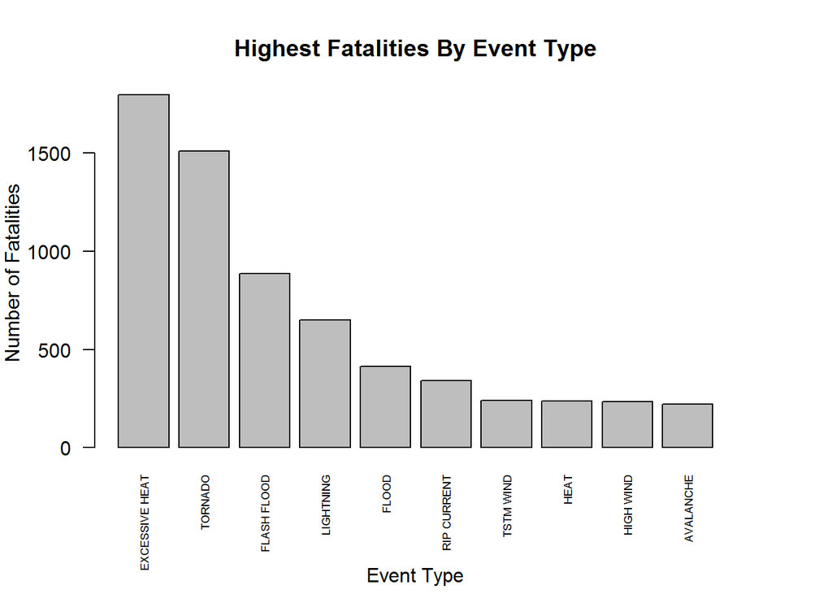

```r
sumFatalities$EVTYPE <- as.character(sumFatalities$EVTYPE)

par(mar=c(6,4,4,4))
barplot(sumFatalities$sum, names.arg=sumFatalities$EVTYPE, cex.names=0.55,font.lab=1.8,las=2,main='Highest Fatalities By Event Type',
        ylab='Number of Fatalities', xlab='', cex.lab = 1)
mtext(side = 1, text = "Event Type", line = 4.7)
```

Estimate and identify events with most injuries.

```r
#Identify Injuries caused by Events
sumInjuries <- group_by(stormData, EVTYPE) %>%
      summarise(sum=sum(INJURIES)) %>%
      arrange(desc(sum)) %>%
      print
```

```
## Source: local data frame [516 x 2]
##
##               EVTYPE   sum
## 1            TORNADO 20667
## 2              FLOOD  6758
## 3     EXCESSIVE HEAT  6391
## 4          LIGHTNING  4141
## 5          TSTM WIND  3629
## 6        FLASH FLOOD  1674
## 7  THUNDERSTORM WIND  1400
## 8       WINTER STORM  1292
## 9  HURRICANE/TYPHOON  1275
## 10              HEAT  1222
## ..               ...   ...
```

Plot Injuries caused by Weather Events.

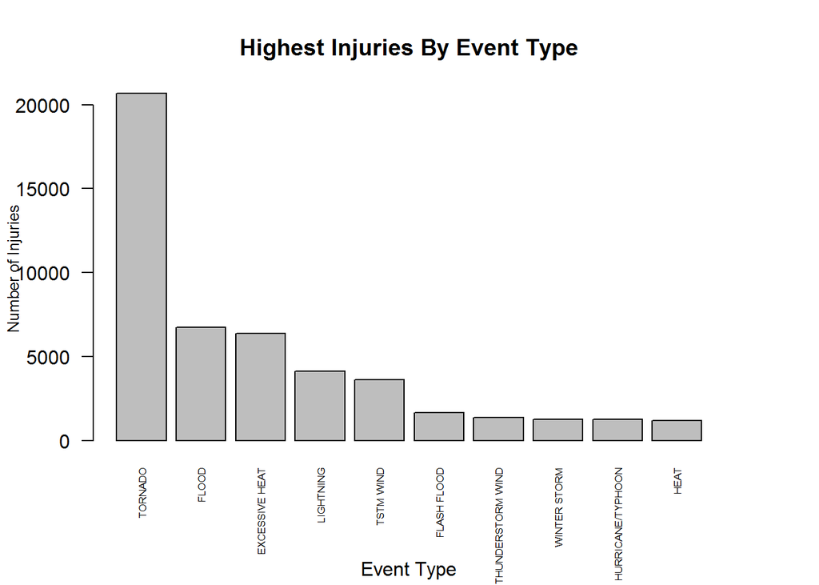

```r
#Identify top 10 Events
sumInjuries <- head(sumInjuries,10)
sumInjuries$EVTYPE <- as.character(sumInjuries$EVTYPE)

par(mar=c(6,4,4,4))
barplot(sumInjuries$sum, names.arg=sumInjuries$EVTYPE, cex.names=0.53, font.lab =1.9, las=2,main='Highest Injuries By Event Type',
        ylab='Number of Injuries', xlab='', cex.lab=0.8)
mtext(side=1, text= 'Event Type', line= 4.8)
```

Estimate and identify events with most property damage.

```r
topPropDmg <- mutate(dataDMG, Est = PROPDMG * EXP) %>%
      group_by(EVTYPE) %>%
      summarise(EstDamage = sum(Est)) %>%
      arrange(desc(EstDamage)) %>%
      print
```

```
## Source: local data frame [178 x 2]
##
##               EVTYPE   EstDamage
## 1  HURRICANE/TYPHOON 69305840000
## 2        STORM SURGE 43193536000
## 3              FLOOD 28944833550
## 4            TORNADO 24616945710
## 5        FLASH FLOOD 15222203910
## 6               HAIL 14595143420
## 7          HURRICANE 11812819010
## 8     TROPICAL STORM  7642475550
## 9          HIGH WIND  5247860360
## 10          WILDFIRE  4758667000
## ..               ...         ...
```

Estimate and identify events with the most crop damage.

```r
#Establish Events with most Damage
topCropDmg <- mutate(dataCropDMG, Est = CROPDMG * EXP) %>%
      group_by(EVTYPE) %>%
      summarise(EstDamage = sum(Est)) %>%
      arrange(desc(EstDamage)) %>%
      print
```

```
## Source: local data frame [83 x 2]
##
##               EVTYPE   EstDamage
## 1            DROUGHT 13367566000
## 2              FLOOD  4974778400
## 3          HURRICANE  2741410000
## 4  HURRICANE/TYPHOON  2607872800
## 5               HAIL  2476029450
## 6        FLASH FLOOD  1334901700
## 7       EXTREME COLD  1288973000
## 8       FROST/FREEZE  1094086000
## 9         HEAVY RAIN   728169800
## 10    TROPICAL STORM   677711000
## ..               ...         ...
```

To calculate overall economic damage we will merge crop and property damage.

```r
mergeData <- merge(topPropDmg, topCropDmg, by.x='EVTYPE', by.y='EVTYPE',all=TRUE)
mergeData[is.na(mergeData)] <- 0 # change NAs to zero.
economicDmg <- rename(mergeData, 'PropDamage'=EstDamage.x, 'CropDamage'=EstDamage.y)
economicDmg <- mutate(economicDmg, TotalDMG = PropDamage + CropDamage)

economicDmg <- arrange(economicDmg, desc(TotalDMG))
totalEconomicDmg <- head(economicDmg,10)
```

Now plot the the top weather events causing the most economic damage.

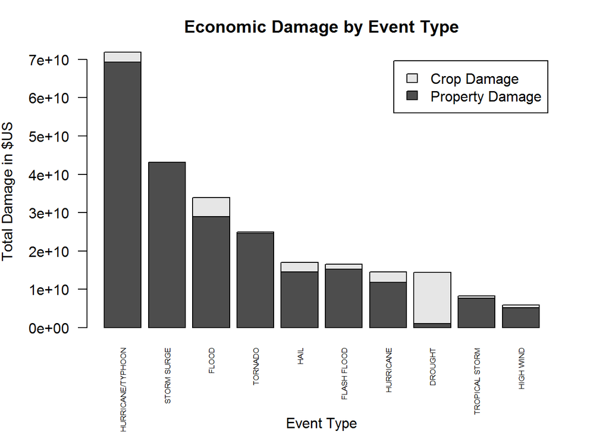

```r
x <- rbind(totalEconomicDmg$PropDamage, totalEconomicDmg$CropDamage)
rownames(x) <- c("Property Damage", "Crop Damage")
colnames(x) <- totalEconomicDmg$EVTYPE


par(mar=c(6,5,3,3))
barplot(x, legend=rownames(x), ylab='', xlab='',  las=2, cex.names=0.53,font.lab=1.8,cex.lab=0.5, main='Economic Damage by Event Type')
mtext(side=1, text= 'Event Type', line= 4.8)
mtext(side=2, text= 'Total Damage in $US', line= 4.1)
```